# Modules & Options

```python
import pandas as pd
from matplotlib import pyplot as plt
import numpy as np

%matplotlib inline
pd.set_option('display.max_rows', None)
```

# Analysis of Sexual and/or Physical Violence on Women

## Data Analyst Information

Data analyzed by: Gabriel S  
Email: gabriel777sh@gmail.com

## Brief

I'm interested in this dataset because I'm aware, that there are women / girls out there suffering from sexual / physical violence conducted by their partner (either it was intentional / unintentional).

I want to correct the awful misconception of "women are not equal to men, therefore they must behave / follow the men unconditionally". Let's pursue the gender equality!

## Dataset

**File** : `eliminationViolenceAgainstWomen.csv`  
**Source** : [https://kaggle.com/utkarshxy](https://www.kaggle.com/utkarshxy/who-worldhealth-statistics-2020-complete?select=eliminateViolenceAgainstWomen.csv)

### Characteristics

- **Location** : Country of interest
- **Indicator** : Proportion of ever-partnered women and girls aged 15-49 years subjected to physical and/or sexual violence by a current or former intimate partner in the previous 12 months
- **Dim1** : Gender
- **Dim2** : Age group
- **First tooltip (?)** : percentage of subjects that receive sexual/physical violence

```python
file = "./dataset/eliminateViolenceAgainstWomen.csv"
df_main: pd.DataFrame = pd.read_csv(file)
```

## Data Cleaning & Extraction

#### Brief Dataset Information

```python
display(df_main.head(5))
display(df_main.info())
```

|  | Location | Period | Indicator | Dim1 | Dim2 | First Tooltip |
| --- | --- | --- | --- | --- | --- | --- |
| 0 | Afghanistan | 2015 | Proportion of ever-partnered women and girls a... | Female | 15-19 years | 28.7 |
| 1 | Afghanistan | 2015 | Proportion of ever-partnered women and girls a... | Female | 20-24 years | 41.1 |
| 2 | Afghanistan | 2015 | Proportion of ever-partnered women and girls a... | Female | 25-29 years | 48.6 |
| 3 | Afghanistan | 2015 | Proportion of ever-partnered women and girls a... | Female | 30-34 years | 49.3 |
| 4 | Afghanistan | 2015 | Proportion of ever-partnered women and girls a... | Female | 35-39 years | 49.1 |

```
<class 'pandas.core.frame.DataFrame'>
RangeIndex: 558 entries, 0 to 557
Data columns (total 6 columns):
 #   Column         Non-Null Count  Dtype
---  ------         --------------  -----
 0   Location       558 non-null    object
 1   Period         558 non-null    object
 2   Indicator      558 non-null    object
 3   Dim1           558 non-null    object
 4   Dim2           558 non-null    object
 5   First Tooltip  558 non-null    float64
dtypes: float64(1), object(5)
memory usage: 26.3+ KB
```

```
None
```

#### Duplicate checking

Check for any duplicate rows.

```python
df_main.duplicated().any()
```

```
False
```

#### Removing "Dim1" column (Gender), because Subjects of Interest are Females Only

```python
df_main = df_main.drop("Dim1", axis=1).drop("Indicator", axis=1)

display(df_main.head(5))
```

|  | Location | Period | Dim2 | First Tooltip |
| --- | --- | --- | --- | --- |
| 0 | Afghanistan | 2015 | 15-19 years | 28.7 |
| 1 | Afghanistan | 2015 | 20-24 years | 41.1 |
| 2 | Afghanistan | 2015 | 25-29 years | 48.6 |
| 3 | Afghanistan | 2015 | 30-34 years | 49.3 |
| 4 | Afghanistan | 2015 | 35-39 years | 49.1 |

#### Renaming to Avoid Confusion

```python
df_main = df_main.rename(
    columns = {
        "Location" : "Countries",
        "Dim2" : "Age Group",
        "First Tooltip" : "Percentage"
    }
)

# display(df_main.head(5))
```

### Countries Subjected for Analysis (Sorted)

```python
df_countries = pd.DataFrame(
    set(df_main["Countries"]),
    columns=["Countries"]
)

df_countries = df_countries.sort_values("Countries")

display(df_countries)
```

|  | Countries |
| --- | --- |
| 59 | Afghanistan |
| 69 | Angola |
| 21 | Armenia |
| 43 | Austria |
| 65 | Azerbaijan |
| 76 | Bangladesh |
| 4 | Belgium |
| 70 | Bolivia (Plurinational State of) |
| 51 | Bulgaria |
| 13 | Burkina Faso |
| 17 | Burundi |
| 94 | Cabo Verde |
| 49 | Cambodia |
| 82 | Cameroon |
| 9 | Central African Republic |
| 71 | Chad |
| 88 | Colombia |
| 41 | Comoros |
| 93 | Cook Islands |
| 46 | Croatia |
| 78 | Cyprus |
| 81 | Czechia |
| 6 | Côte d’Ivoire |
| 47 | Democratic Republic of the Congo |
| 11 | Denmark |
| 103 | Dominican Republic |
| 90 | Ecuador |
| 54 | Egypt |
| 75 | El Salvador |
| 30 | Equatorial Guinea |

[output cut: 77 more lines]

### Periods (sorted)

```python
df_periods = pd.DataFrame(
    set(df_main['Period']),
    columns=["Period"]
)

df_periods = df_periods.sort_values("Period")

display(df_periods)
```

|  | Period |
| --- | --- |
| 12 | 2000 |
| 16 | 2005 |
| 7 | 2006 |
| 14 | 2007 |
| 5 | 2008 |
| 17 | 2009 |
| 1 | 2010 |
| 2 | 2010-2011 |
| 10 | 2011 |
| 18 | 2011-2012 |
| 8 | 2012 |
| 13 | 2013 |
| 0 | 2013-2014 |
| 15 | 2014 |
| 9 | 2014-2015 |
| 3 | 2015 |
| 19 | 2015-2016 |
| 4 | 2016 |
| 6 | 2016-2017 |
| 11 | 2017 |

### Age Group (sorted)

```python
df_age_groups = pd.DataFrame(
    set(df_main['Age Group']),
    columns=["Age Group"]
)

df_age_groups = df_age_groups.sort_values("Age Group")
display(df_age_groups)
```

|  | Age Group |
| --- | --- |
| 17 | 15-19 years |
| 12 | 15-24 years |
| 13 | 15-44 years |
| 7 | 15-49 years |
| 15 | 18-19 years |
| 3 | 18-24 years |
| 10 | 18-49 years |
| 0 | 18-50 |
| 11 | 20-24 years |
| 2 | 20-29 years |
| 5 | 25-29 years |
| 1 | 25-34 years |
| 19 | 30-34 years |
| 18 | 30-35 years |
| 6 | 30-39 years |
| 4 | 35-39 years |
| 9 | 35-44 years |
| 14 | 40-44 years |
| 16 | 40-49 years |
| 8 | 45-49 years |
| 20 | 45-59 years |

# Data Analysis

### Data Merging

As we have seen here:

```python
display(df_periods)
```

|  | Period |
| --- | --- |
| 12 | 2000 |
| 16 | 2005 |
| 7 | 2006 |
| 14 | 2007 |
| 5 | 2008 |
| 17 | 2009 |
| 1 | 2010 |
| 2 | 2010-2011 |
| 10 | 2011 |
| 18 | 2011-2012 |
| 8 | 2012 |
| 13 | 2013 |
| 0 | 2013-2014 |
| 15 | 2014 |
| 9 | 2014-2015 |
| 3 | 2015 |
| 19 | 2015-2016 |
| 4 | 2016 |
| 6 | 2016-2017 |
| 11 | 2017 |

For this case, I want the datasets to be yearly. This means that the data representation will be **assumed to be taken at the end of the year**.

So I need to merge the category:

- "2010-2011" : merge with "2011"
- "2011-2012" : merge with "2012"
- "2013-2014" : merge with "2014"
- "2014-2015" : merge with "2015"
- "2015-2016" : merge with "2016"
- "2016-2017" : merge with "2017"

```python
df_periods_merged = []
period_merge_pattern = {
    "2010-2011" : "2011",
    "2011-2012" : "2012",
    "2013-2014" : "2014",
    "2014-2015" : "2015",
    "2015-2016" : "2016",
    "2016-2017" : "2017",
}

for key, target in period_merge_pattern.items():
    # concat the data
    concated = pd.concat([
      df_main[ df_main["Period"] == key ],
      df_main[ df_main["Period"] == target ]
    ])

    # Get index of periods that has "yyyy-yyyy" format
    key_indexes = list(concated[ concated["Period"] == key].index)

    # Change "yyyy-yyyy" to "yyyy" format
    for index in key_indexes:
        concated.at[index, "Period"] = target

    # append to list of merged dataframes
    df_periods_merged.append(concated)

# Concat the data for good & check for duplicates
df_periods_merged = pd.concat(df_periods_merged)

display(df_periods_merged.duplicated().any())
display(df_periods_merged.head(5))
```

```
False
```

|  | Countries | Period | Age Group | Percentage |
| --- | --- | --- | --- | --- |
| 173 | Fiji | 2011 | 18-24 years | 47.2 |
| 174 | Fiji | 2011 | 25-29 years | 41.6 |
| 175 | Fiji | 2011 | 30-34 years | 30.8 |
| 176 | Fiji | 2011 | 35-39 years | 25.8 |
| 177 | Fiji | 2011 | 40-44 years | 23.0 |

Next, I want to concat the datas that I didn't process, with the data I just processed, to rebuild a new main dataframe. Those datas are the datas of period:

###### Extracting the normal datas

```python
normal_periods_key = [
    "2000",
    "2005",
    "2006",
    "2007",
    "2008",
    "2009",
    "2010",
    "2012",
    "2013"
]

# Concat the normal period datas
df_normal_datas = []
for key in normal_periods_key:
    df_normal_datas.append(
        df_main[
             df_main["Period"] == key
        ]
    )

df_normal_datas = pd.concat(df_normal_datas)

display(df_normal_datas.duplicated().any())
display(df_normal_datas.head(5))
```

```
False
```

|  | Countries | Period | Age Group | Percentage |
| --- | --- | --- | --- | --- |
| 434 | Samoa | 2000 | 15-49 years | 22.0 |
| 59 | Cabo Verde | 2005 | 15-49 years | 7.8 |
| 418 | Republic of Moldova | 2005 | 15-19 years | 15.1 |
| 419 | Republic of Moldova | 2005 | 20-24 years | 14.6 |
| 420 | Republic of Moldova | 2005 | 25-29 years | 14.5 |

###### Merging the "normal datas" with the "processed data"

Here, I used outer join, since I assumed there's a possibility of duplicate datas if I used normal concatenation. This possibility arises since there are many overlapping periods when the data was taken.

I use outer join, because it's just the same as concating both the data & dropping the duplicate rows.

```python
df_main_new = pd.merge(df_normal_datas, df_periods_merged, how="outer")

print(f"Duplicated data: {df_main_new.duplicated().any()}\n")
display(df_main_new.info())
display(df_main_new.head(5))
```

```
Duplicated data: False

<class 'pandas.core.frame.DataFrame'>
Int64Index: 558 entries, 0 to 557
Data columns (total 4 columns):
 #   Column      Non-Null Count  Dtype
---  ------      --------------  -----
 0   Countries   558 non-null    object
 1   Period      558 non-null    object
 2   Age Group   558 non-null    object
 3   Percentage  558 non-null    float64
dtypes: float64(1), object(3)
memory usage: 21.8+ KB
```

```
None
```

|  | Countries | Period | Age Group | Percentage |
| --- | --- | --- | --- | --- |
| 0 | Samoa | 2000 | 15-49 years | 22.0 |
| 1 | Cabo Verde | 2005 | 15-49 years | 7.8 |
| 2 | Republic of Moldova | 2005 | 15-19 years | 15.1 |
| 3 | Republic of Moldova | 2005 | 20-24 years | 14.6 |
| 4 | Republic of Moldova | 2005 | 25-29 years | 14.5 |

#### End of data merging

And now, I'll have a clean datas, with non-null entries and no duplicates! Such clean datas are sophisticating to work on... But wait, there's something unique about the data! Yes, it's at the period: 2000. There's only 1 country that has percentage data, and also, after 2000, there's a huge time-gap until 2005. So in this case, I decide to **drop the period 2000**, and change my period of interest from **2005-2017**.

```python
df_main_new = df_main_new.drop(
    df_main_new[df_main_new["Period"] == "2000"].index
)

display(df_main_new.head(5))
```

|  | Countries | Period | Age Group | Percentage |
| --- | --- | --- | --- | --- |
| 1 | Cabo Verde | 2005 | 15-49 years | 7.8 |
| 2 | Republic of Moldova | 2005 | 15-19 years | 15.1 |
| 3 | Republic of Moldova | 2005 | 20-24 years | 14.6 |
| 4 | Republic of Moldova | 2005 | 25-29 years | 14.5 |
| 5 | Republic of Moldova | 2005 | 30-34 years | 15.9 |

Now we can procceed on to gaining insights from the processed data!

# Max & Min at 1 Point of Time

```python
max_percentage =  df_main_new[
    df_main_new["Percentage"] == df_main_new["Percentage"].max()
]

min_percentage = df_main_new[
    df_main_new["Percentage"] == df_main_new["Percentage"].min()
]

display(
    pd.merge(min_percentage, max_percentage, how="outer")
)
```

|  | Countries | Period | Age Group | Percentage |
| --- | --- | --- | --- | --- |
| 0 | Armenia | 2016 | 15-19 years | 0.0 |
| 1 | Equatorial Guinea | 2011 | 25-29 years | 58.5 |

# Data Visualization

#### Global data for ease of calculation

```python
# Total percentage of no violence
subjects_no_violence = 100.0 - np.array(df_main_new["Percentage"])
subjects_no_violence_sum = subjects_no_violence.sum()
print("Subjects that are NOT exposed to sexual / physical violence (cumulative %): ")
print(subjects_no_violence_sum)

# Total percentage of violence
subjects_with_violence = np.array(df_main_new["Percentage"])
subjects_with_violence_sum = subjects_with_violence.sum()
print("Subjects that are exposed to sexual / physical violence (cumulative %): ")
print(subjects_with_violence_sum)

# Total of all percentage
subjects_total = subjects_with_violence_sum + subjects_no_violence_sum
print("Total (cumulative %): ")
print(subjects_total)
```

```
Subjects that are NOT exposed to sexual / physical violence (cumulative %):
45863.94
Subjects that are exposed to sexual / physical violence (cumulative %):
9836.060000000001
Total (cumulative %):
55700.0
```

##### Percentage of Women Exposed to Physical / Sexual Violence from 2005 to 2017

```python
print(f"{100 * subjects_with_violence_sum / subjects_total} %")
```

```
17.658994614003593 %
```

#### Sexual/Physical Violence Throughout the Year

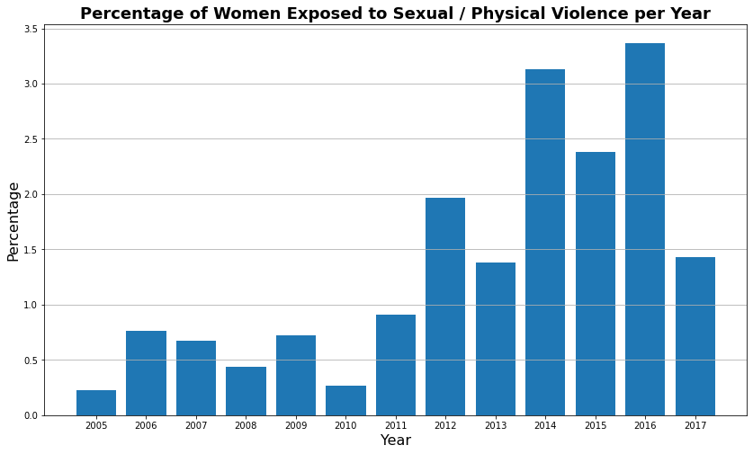

```python
# Normalize the value
period_group = df_main_new.sort_values("Period")
# For labelling
years = period_group["Period"].drop_duplicates()

period_group = np.array(period_group.groupby("Period", sort=False).sum()).flatten()
period_group_relative = 100 * period_group / subjects_total


title_opts = {
    "fontsize" : 18,
    "fontweight" : "bold"
}

label_opts = {
    "fontsize" : 16,
}

plt.figure(1, figsize=(14,8))
plt.bar(years, period_group_relative)
plt.title("Percentage of Women Exposed to Sexual / Physical Violence per Year", fontdict=title_opts)
plt.xlabel("Year", fontdict=label_opts)
plt.ylabel("Percentage", fontdict=label_opts)
plt.grid(axis="y")
plt.show()
```

##### Percentage of physical / sex violence by Country

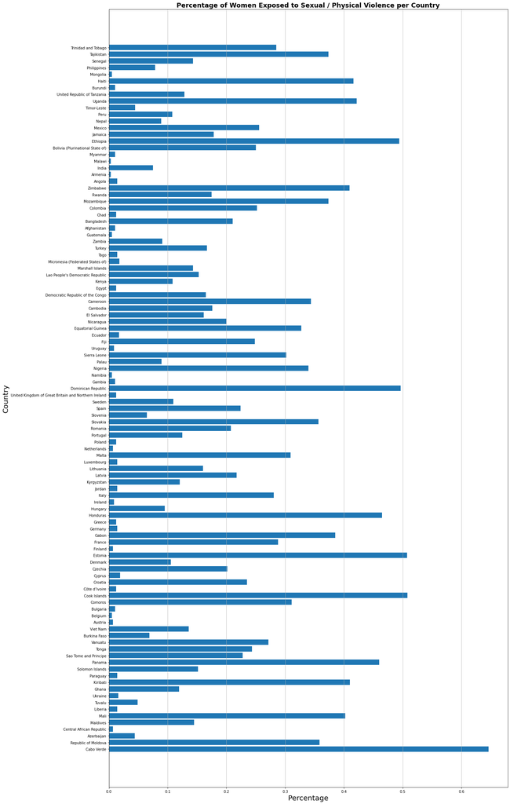

```python
# Normalize the value
country_group = np.array(df_main_new.groupby("Countries").sum()).flatten()
country_group_relative = 100 * country_group / subjects_total

# For labelling
countries = df_main_new["Countries"].drop_duplicates()

title_opts = {
    "fontsize" : 18,
    "fontweight" : "bold"
}

label_opts = {
    "fontsize" : 20,
}

plt.figure(1, figsize=(20,40))
plt.barh(countries, country_group_relative)
plt.title("Percentage of Women Exposed to Sexual / Physical Violence per Country", fontdict=title_opts)
plt.ylabel("Country", fontdict=label_opts)
plt.xlabel("Percentage", fontdict=label_opts)
plt.grid("both", axis="x")
plt.show()
```

##### Percentage of Physical / Sexual Violence by Age Group per Year

Relative to the total women in the populace (women that are not subjected to the analysis are not counted)

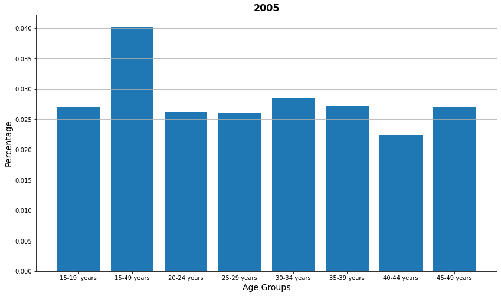

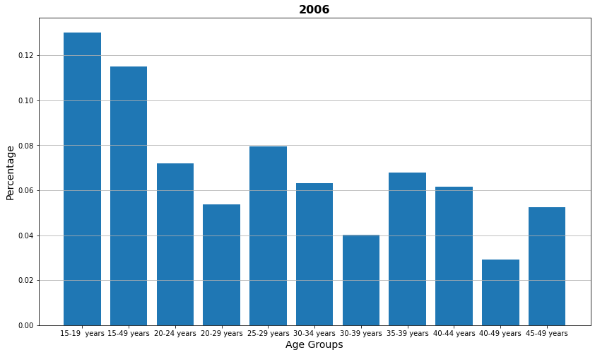

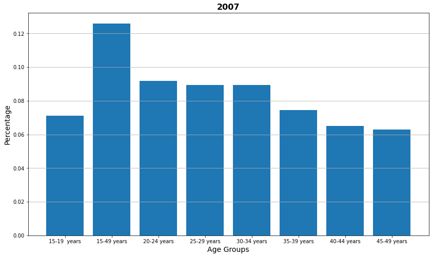

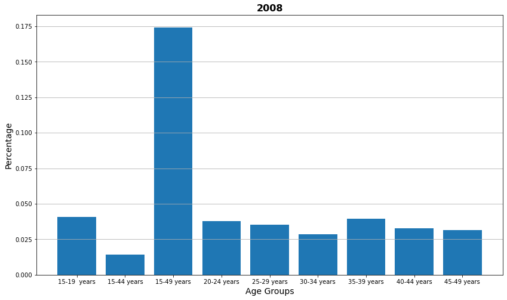

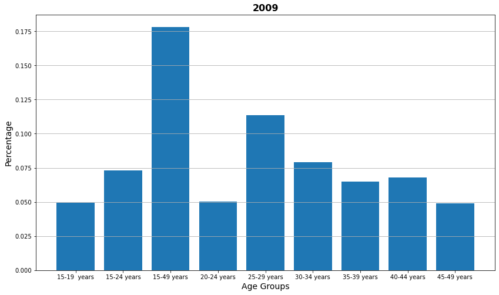

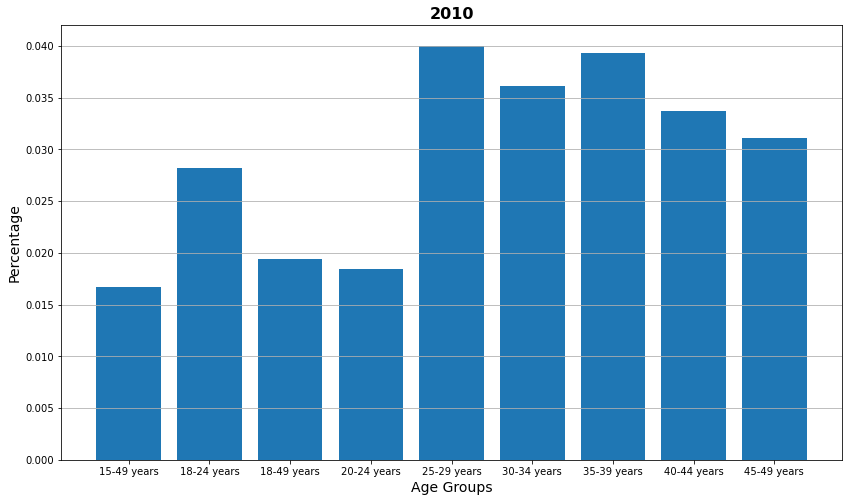

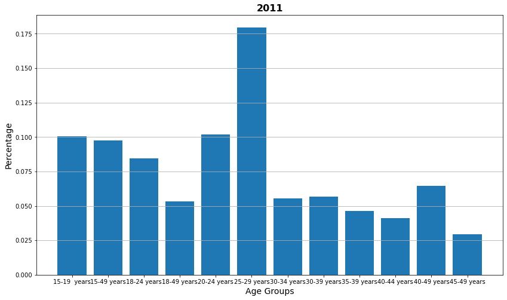

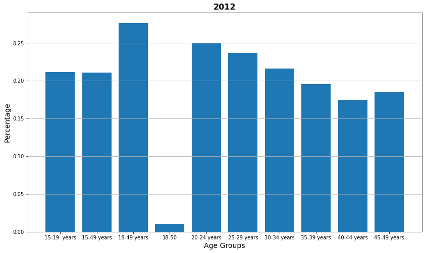

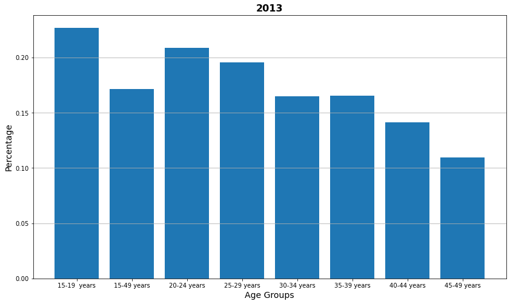

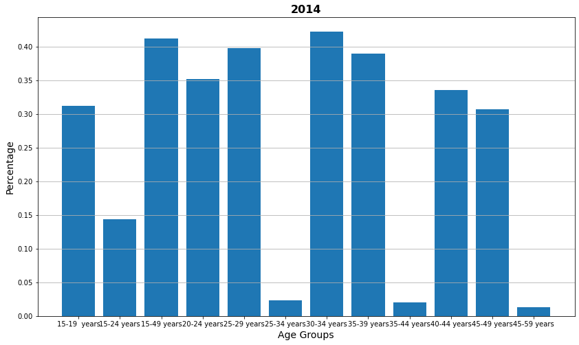

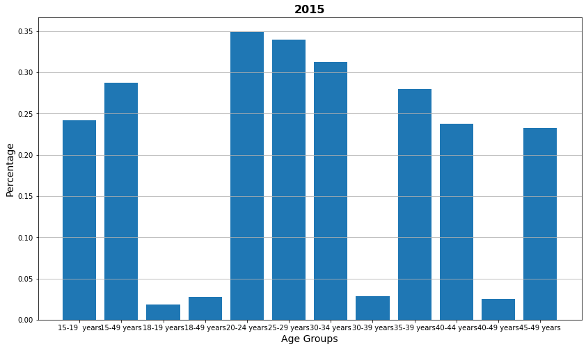

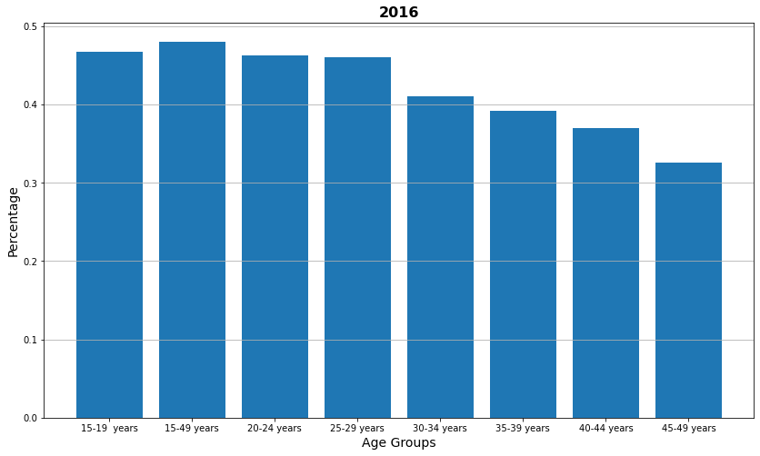

[1 more figures not shown]

```python
age_groups = df_main_new.groupby(["Period", "Age Group"], as_index=False).sum()

age_group_dict = {}
age_group_keys = [f"{x}" for x in range(2005, 2018)]

# Plotting options
fig_count = 0
title_opts = {
    "fontweight" : "bold",
    "fontsize" : 16
}

label_opts = {
    "fontsize" : 14
}

for period in age_group_keys:
    fig_count += 1
    data = age_groups[
        age_groups["Period"] == period
    ]

    data_np_arr = np.array(data["Percentage"])
    data_np_arr = 100 * data_np_arr / subjects_total
    data_labels = np.array(data["Age Group"])

    plt.figure(fig_count, figsize=(14, 8))
    plt.bar(data_labels, data_np_arr)
    plt.title(period, fontdict=title_opts)
    plt.xlabel("Age Groups", fontdict=label_opts)
    plt.ylabel("Percentage", fontdict=label_opts)
    plt.grid(axis="y")

plt.show()
```